# Loan

El dataset ./datos/loan2.csv contiene ciertos registros relacionados con préstamos. Cada registro se corresponde con los datos de un préstamo.

**1.)** Crear un DataFrame llamado `loan` con los datos del fichero. No te olvides de importar el módulo necesario para realizar la creación del DataFrame.

```python
# Sol:
```

**2.)** Muestra las últimas 10 filas del DataFrame que has creado en el apartado anterior.

```python
# Sol:
```

**3.)** ¿Cuántas filas tiene la tabla?

```python
# Sol
```

**4.)** Crea otro dataframe llamado `loan2` con los datos del fichero, pero esta vez realiza la carga únicamente de las siguientes columnas:

```
cols = ['member_id', 'loan_amnt', 'term' , 'int_rate', 'purpose',
         'application_type' , 'addr_state', 'annual_inc',
         'loan_status' ]
```

```python
# Sol:
```

**5.)** Calcular los estadísticos `mínimo`, `máximo`, `media` y `desviación típica` de la columna `int_rate`.

```python
# Sol:
```

**6.)** Seleccionar los préstamos cuyo importe (valor en la columna `loan_amnt`) sea mayor de 33000 euros.

```python
# Sol:
```

**7.)** Representa mediante un histograma el tipo de interés `int_rate`.

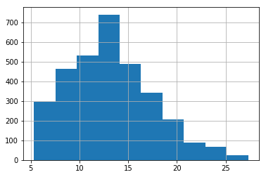

```python
# Sol:
import matplotlib.pyplot as plt
%matplotlib inline

loan.int_rate.hist();
```

**8.)** Nos interesa conocer la finalidad de los préstamos (columna `purpose`). Calcula el número de préstamos por finalidad.

```python
# Sol:
```

**9.)** En cuanto a la duración del préstamo, columna `term`, nos encontramos con préstamos a 36 meses y 60 meses.

Transforma dicha columna de forma que no contenga valores de tipo `str`, sino de tipo `int`, es decir:

- valor 36 en lugar de ' 36 months'
- valor 60 en lugar de ' 60 months'

```python
# Sol:
```

**10.)** Calcula de la correlación entre la cantidad prestada `loan_amnt`, renta `annual_inc` y el tipo de interés `int_rate`.

```python
# Sol:
```

**11.)** Importe del préstamo (loan_amnt): a cada uno de los préstamos le asignaremos una categoría dependiento del importe del préstamo:

- low (importe < 8000)
- medium-low, (importe < 13000),
- medium-high, (importe < 18000)
- high (resto)

Diseñar una función `clasificar_cantidad` que devuelva una categoría para un importe dado de entrada.

Añadir una nueva columna a la tabla de préstamos con información de la categoría.

```python
# Sol:
```